# EDA - Histograms

Khaled Sobeh

5/5/2022

Data Visualization: Histograms / continuous data types

Histogram is a kind of graphs that we use to represent a continuous variable. 1. By saying continuous, we mean a variable that can any value in an interval(such as: height, acceleration, length, time, temperature, age…), it’s a quantitative variable that we can summarize.

Data structure in R: 1. integer. 2. numeric.

Histograms with histograms we can check if the “pattern” of a variable ,if the variable is: “symmetric”, “skewed left” or “right”, “unimodal”(normally distributed), “bimodal” or “multimodal”.

I will try to use only ggplot2 functions, except if the alternative is much easier, with much less code to write. note: plot_grid() function will be used a lot. I used it just to combine plots, as we shall see.

So, let’s start.

Loading the libraries, and getting the data.

```r
library(ggplot2)
library(priceR)
library(dplyr)
library(forcats)
library(cowplot)
library(ISLR)
```

```r
auto <- Auto
auto$origin <- as.factor(auto$origin)
auto$cylinders <- as.factor(auto$cylinders)
auto <- select(auto, -name)
```

```r
str(auto)
```

```
## 'data.frame':    392 obs. of  8 variables:
##  $ mpg         : num  18 15 18 16 17 15 14 14 14 15 ...
##  $ cylinders   : Factor w/ 5 levels "3","4","5","6",..: 5 5 5 5 5 5 5 5 5 5 ...
##  $ displacement: num  307 350 318 304 302 429 454 440 455 390 ...
##  $ horsepower  : num  130 165 150 150 140 198 220 215 225 190 ...
##  $ weight      : num  3504 3693 3436 3433 3449 ...
##  $ acceleration: num  12 11.5 11 12 10.5 10 9 8.5 10 8.5 ...
##  $ year        : num  70 70 70 70 70 70 70 70 70 70 ...
##  $ origin      : Factor w/ 3 levels "1","2","3": 1 1 1 1 1 1 1 1 1 1 ...
```

The variables that I used from the dataset: 1) acceleration: continuous variable.

## a reminder.

If you forget one day how to make plot with ggplot2(Please don’t…), then you have to remember that you have to pass these three: 1) ggplot(and_here_the_dataset_name) 2) aes(x = the_variable_name_that_you_want_to_visualize, y = sec_col…) you can pass this aes thing(you should remember this) in ggplot() or geom_..() function. 3) geom_ the_plot_that_you_want: geom_bar(), geom_boxplot()….. so you should have: ggplot(travel,aes(acceleration)) + geom_bar() |or| ggplot(travel) + geom_bar(aes(acceleration))

## The most basic histogram:

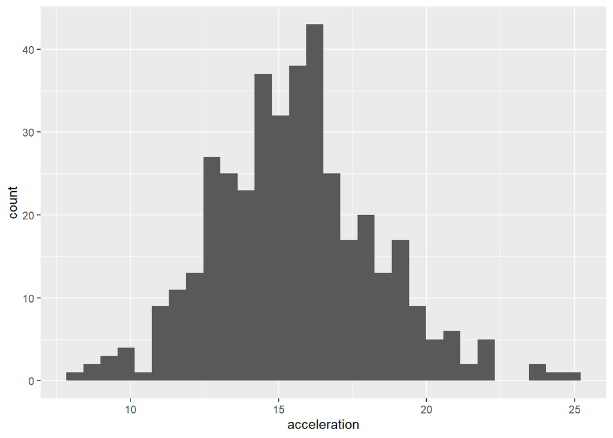

```r
ggplot(auto,aes(acceleration)) + geom_histogram()
```

we can also set the aesthetic in the geom function:

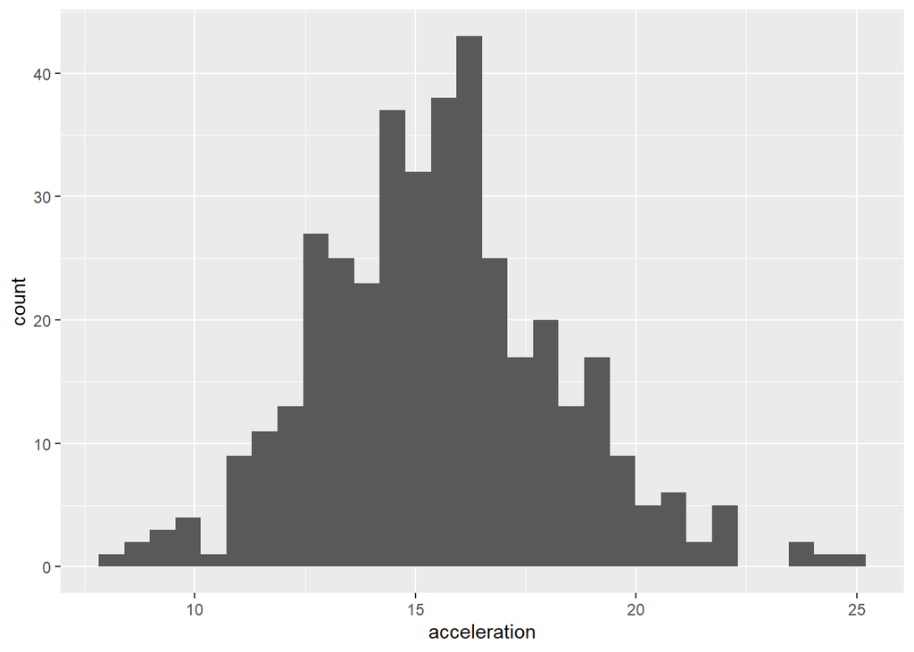

```r
ggplot(auto) + geom_histogram(aes(acceleration))
```

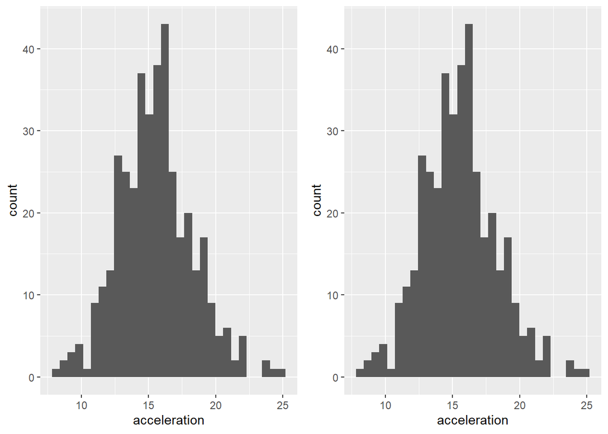

```r
plot_grid(ggplot(auto,aes(acceleration)) + geom_histogram(),
          ggplot(auto) + geom_histogram(aes(acceleration)))
```

### bins and binwidth

bins control the number of bins(‘bars’) binwidth control the width of the bins by x axis

more clear example: a contiuous variable: values between 1 and 100([1,100]):

```r
set.seed(1)
df <- data.frame(col_1 = purrr::rdunif(1000,1,100))
```

[figure not shown]

```r
plot_grid(ggplot(df,aes(col_1)) + geom_histogram(bins = 5, fill = "lightblue", colour = "black") +
            ggtitle('bins = 5') + scale_x_continuous(),
          ggplot(df,aes(col_1)) + geom_histogram(binwidth = 20, fill = "lightblue", colour = "black") +
            ggtitle('binwidth = 5'))
```

geom_histogram parameters:

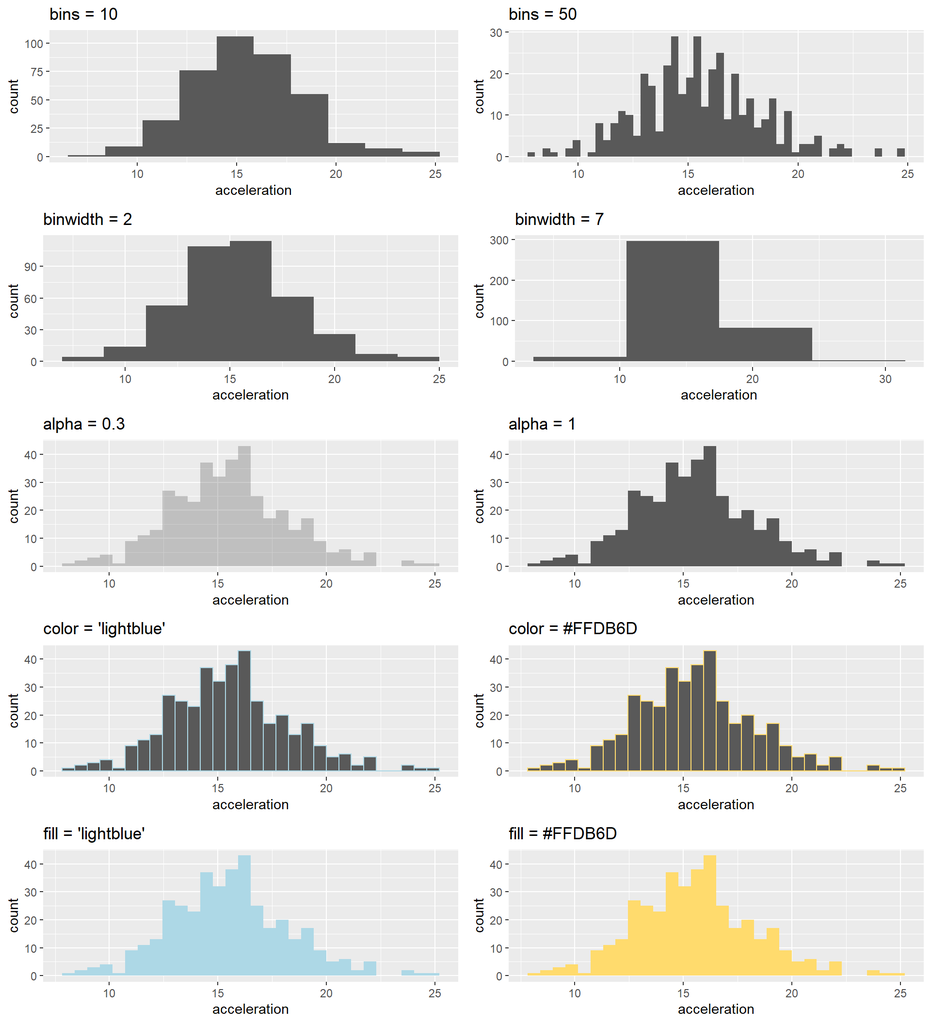

```r
plot_grid(ggplot(auto, aes(acceleration)) + geom_histogram(bins = 10) + ggtitle("bins = 10"),
          ggplot(auto, aes(acceleration)) + geom_histogram(bins = 50) + ggtitle("bins = 50"),
          ggplot(auto, aes(acceleration)) + geom_histogram(binwidth = 2) + ggtitle("binwidth = 2"),
          ggplot(auto, aes(acceleration)) + geom_histogram(binwidth = 7) + ggtitle("binwidth = 7"),
          ggplot(auto, aes(acceleration)) + geom_histogram(alpha = 0.3) + ggtitle("alpha = 0.3"),
          ggplot(auto, aes(acceleration)) + geom_histogram(alpha = 1) + ggtitle("alpha = 1"),
          ggplot(auto, aes(acceleration)) + geom_histogram(color = 'lightblue') + ggtitle("color = 'lightblue'"),
          ggplot(auto, aes(acceleration)) + geom_histogram(color = '#FFDB6D') + ggtitle("color = #FFDB6D"),
          ggplot(auto, aes(acceleration)) + geom_histogram(fill = 'lightblue') + ggtitle("fill = 'lightblue'"),
          ggplot(auto, aes(acceleration)) + geom_histogram(fill = '#FFDB6D') + ggtitle("fill = #FFDB6D"),
          #ggplot(auto, aes(acceleration)) + geom_histogram() + ggtitle(""),
          #ggplot(auto, aes(acceleration)) + geom_histogram() + ggtitle(""),
          ncol = 2)
```

### change font size…

change font size:

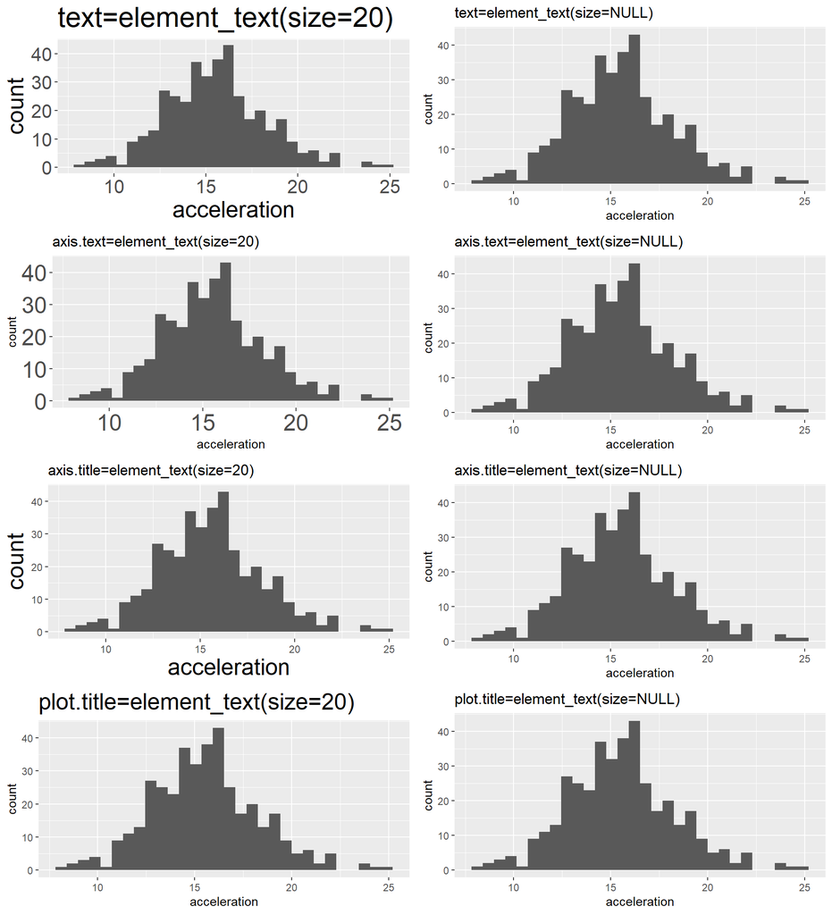

```r
h0 <- ggplot(auto,aes(acceleration)) + geom_histogram()
plot_grid(h0 + theme(text=element_text(size=20)) + ggtitle('text=element_text(size=20)'),
          h0 + ggtitle('text=element_text(size=NULL)'),
          h0 + theme(axis.text=element_text(size=20)) + ggtitle('axis.text=element_text(size=20)'),
          h0 + ggtitle('axis.text=element_text(size=NULL)'),
          h0 + theme(axis.title=element_text(size=20)) + ggtitle('axis.title=element_text(size=20)'),
          h0 + ggtitle('axis.title=element_text(size=NULL)'),
          h0 + theme(plot.title=element_text(size=20)) + ggtitle('plot.title=element_text(size=20)'),
          h0 + ggtitle('plot.title=element_text(size=NULL)'),
          ncol = 2)
```

### add title, rename labs…

now we will gonna add a title, change x and y names. We have two options: 1)

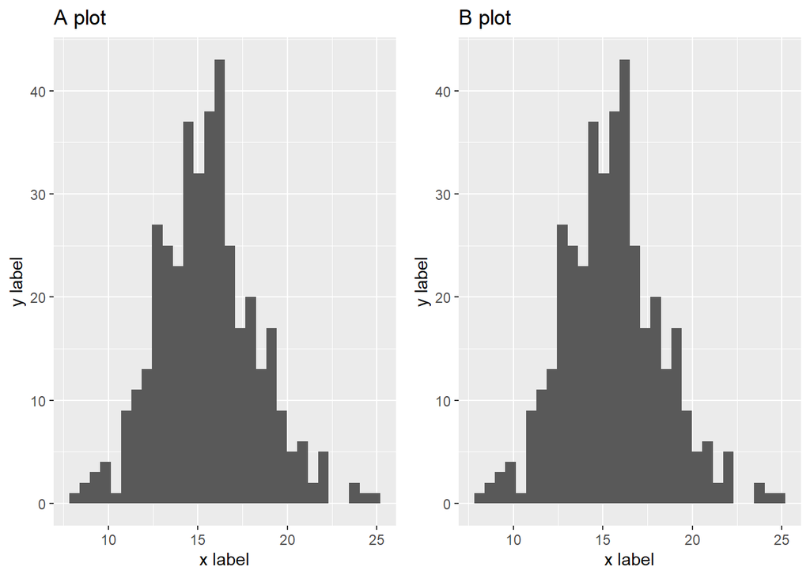

```r
A <-  h0 + labs(x = 'x label', y = 'y label', title = 'A plot')
##
B <- h0 + xlab('x label') + ylab('y label') + ggtitle('B plot')
plot_grid(A,B)
```

other useful stuff with labs function: 2)

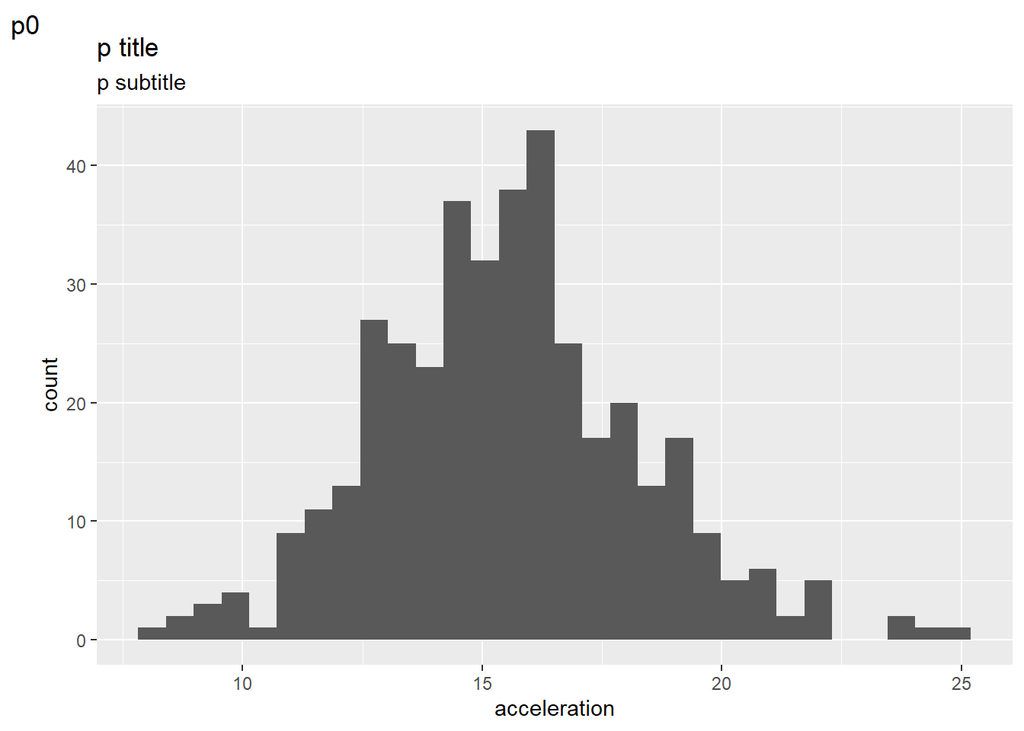

```r
h0 + labs(title = 'p title', subtitle = 'p subtitle', tag = 'p0')
```

### change axis limits.

change x axis limits:

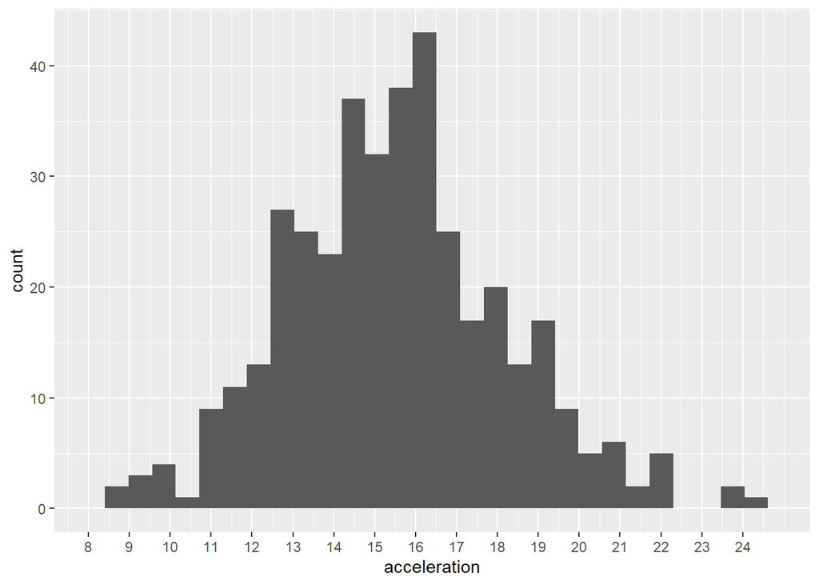

```r
h0 +  scale_x_continuous(limits=c(min(auto$acceleration),max(auto$acceleration)), #future use: just change df$col
                         breaks=seq(min(auto$acceleration),max(auto$acceleration),1)) #you can change the by(100)
```

now you can add avg line….

Bivariate graph: showing the relationship between two variables.

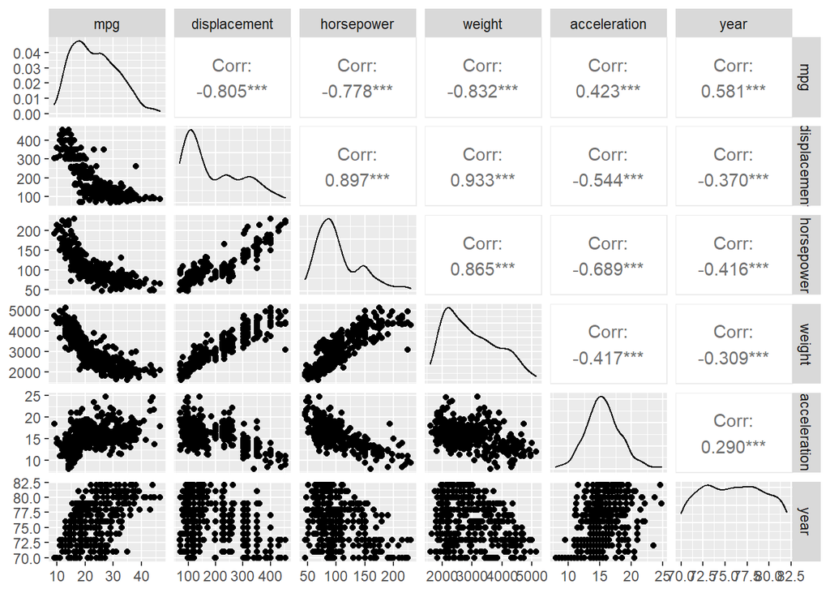

```r
GGally::ggpairs(select(auto,-c(origin,cylinders)))
```